# Case Study 5: Extra, extra, code all about it

Alice Pao

June 21, 2022

```r
library(tidyverse)
library(maps)
library(lubridate)
abc <- read.csv("https://storybench.org/reinventingtv/abc7ny.csv")
kcra <- read.csv("https://storybench.org/reinventingtv/kcra.csv")
dat <- rbind(abc, kcra) %>%
  select(datetime, headline, feed_name)
city <- maps::us.cities
```

### Background

You are working for management consulting agency A.T. Kearney which produces the Global Cities report. They have put you on a team in charge of developing a new report - the USA Cities report - which identifies the most influential cities in the United States.

Your manager would like to explore using the frequency with which a city appears in news headlines as a contributing factor to their city rankings.

### Introduction

From 2 news outlets, KCRA and ABC7NY spanning from July 18, 2017 - Jan 16, 2018, we identified top 15 cities with the highest headline count.

In this project, we specifially used str_extract to find the mentioned cities.

### Question 1

> Find the top 15 mentioned cities in headlines

The most 3 mentioned cities we found are Sacramento, New York, and Las Vegas. This result is reasonable because these are 3 capital cities of California, New York State, and Nevada.

At first, Sandy was one of the top 15 but we latter realized the search included Superstorm Sandy and Sandy Kenyon, a report. Since Sandy, UT is only mentioned in headline 7 times(less than the 15th mentioned city), we decided to remove it.

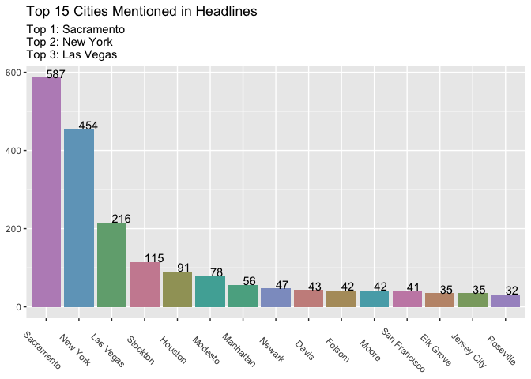

```r
# wrangle city data
city <- city %>%
  separate(name, into = c("city", "state"), -2) %>%
  arrange(desc(str_length(city))) %>%
  select(city, state)

citystri <- str_flatten(city$city, collapse = "|")

# find most mentioned 15 cities in headlines
top15 <- dat %>%
  mutate(mentioned_city = str_extract(headline, citystri)) %>%
  filter(mentioned_city != "Sandy ") %>%
  group_by(mentioned_city) %>%
  mutate(city_count = n()) %>%
  drop_na() %>%
  distinct(mentioned_city, city_count) %>%
  arrange(desc(city_count)) %>%
  head(15)

# exclude Superstorm Sandy & Sandy Kenyon
# dat$sandy <- dat %>%
#   mutate(sandy = str_detect(headline, "(?<!Superstorm )Sandy(?! Kenyon)(?! Hook)")) %>%
#   filter(sandy == TRUE)

# Charlotte vs Charlottesville
# dat %>%
#   mutate(city = str_extract(headline, "Charlottesville|Charlotte")) %>%
#   count(city)

top15 %>%
  ggplot(aes(x = reorder(mentioned_city, -city_count), y = city_count, fill = mentioned_city))+
  geom_col()+
  theme(
    axis.text.x = element_text(angle = -45),
    axis.title.x = element_blank(),
    axis.title.y = element_blank(),
    legend.position = "none"
  )+
  scale_fill_hue(c=40)+
  labs(
    title = "Top 15 Cities Mentioned in Headlines",
    subtitle = "Top 1: Sacramento \nTop 2: New York \nTop 3: Las Vegas",
  )+
  # add number labels
  geom_text(aes(label=city_count),vjust=0,hjust=0)
```

### Question 2

> Headline count for each city every month

From the below line chart, we notice that there isn’t an obvious change for each city; However, for top 3 mentioned cities, New York, Sacramento, and Las Vegas, we see different pattern of trends.

New York: The city has been most mentioned in October, November, and December.

Sacramento: August is the month when it shows up to news headline and the number went down a little but rised again in November and December.

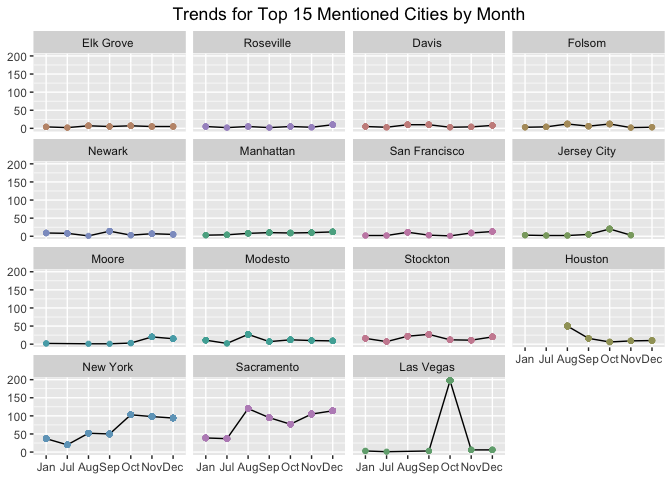

```r
# split datetime column and change to date type
top15_month <- dat %>%
  mutate(mentioned_city = str_extract(headline, citystri)) %>%
  separate(datetime, into = c("date", "time"), sep = " at ", remove = TRUE)
  # change to datetime type
top15_month$date <- as.Date(top15_month$date, format = "%B %d, %Y")
  # extract month
top15_month$month <- month(top15_month$date, label = TRUE)

topcities <- str_flatten(top15$mentioned_city, collapse = "|")

# filter top 15 cities
top15_month$filter <- str_detect(top15_month$mentioned_city, pattern = topcities)
top15_month <- top15_month %>%
  filter(filter == "TRUE") %>%
  filter(mentioned_city != "West Sacramento ") %>%
  select(-filter) %>%
  # group_by month
  group_by(mentioned_city, month) %>%
  # city_count
  mutate(count = n())

top15_month %>% ggplot(aes(x = month, y = count, group = mentioned_city))+
  geom_line()+
  geom_point(aes(color = mentioned_city))+
  facet_wrap(.~reorder(mentioned_city, count))+
  xlab(NULL)+
  ylab(NULL)+
  labs(
    title = "Trends for Top 15 Mentioned Cities by Month",
  )+
  theme(
    legend.position = "none",
    plot.title = element_text(hjust = 0.5))+
  scale_color_hue(c = 40)
```

### Question 3

> Houston, TX and Charlotte, NC monthly comparison

When comparing Houston and Charlotte, we conclude that Houston has more mentions than Charlotte. Charlotte has only been mentioned in January, July and December. On the flip side, Houston has more than 60 mentions in total from August to December.

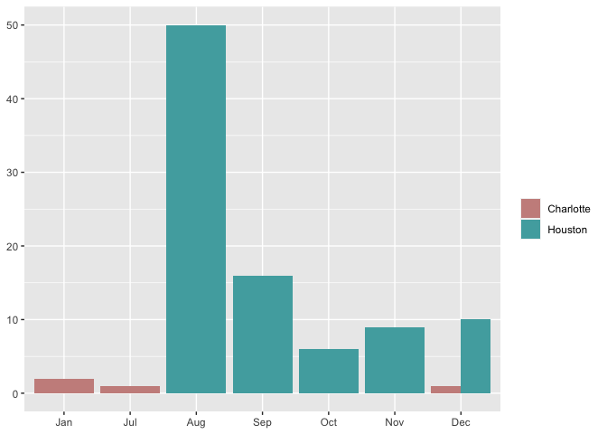

```r
# comparing the headlines generated about Houston, TX and Charlotte, NC over time (by month)

q3dat <- dat %>%
  mutate(mentioned_city = str_extract(headline, citystri)) %>%
  separate(datetime, into = c("date", "time"), sep = " at ", remove = TRUE)
  # change to datetime type
q3dat$date <- as.Date(q3dat$date, format = "%B %d, %Y")
  # extract month
q3dat$month <- month(q3dat$date, label = TRUE)

q3dat <- q3dat %>%
  group_by(mentioned_city, month) %>%
  mutate(count = n()) %>%
  drop_na() %>%
  distinct(mentioned_city, count, month) %>%
  filter(mentioned_city == "Houston " | mentioned_city == "Charlotte ")

q3dat %>%
  ggplot(aes(x = month, y = count, fill = mentioned_city))+
  geom_col(position = "dodge")+
  scale_fill_hue(c = 40)+
  theme(
    axis.title.x = element_blank(),
    axis.title.y = element_blank()
  )+
  labs(
    fill = ""
  )
```